# Sostenibilidad 35

cuota de 100 m³/semana: pico 130 → 100 m³ nivelado, exceso 120 → 0 m³; cabe tras nivelar; hidrante: 23 k€ esperados

# Enunciado

Una obra de urbanización consume agua en el curado del hormigón, el riego de compactación de los rellenos, el control del polvo y el lavado de maquinaria. El cuadro de prelaciones, las duraciones (semanas) y el consumo semanal de agua de cada actividad (`agua_m3`, m³ por semana mientras está en curso) se adjuntan. El agua se toma de la red municipal con un contador de obra (2.5 €/m³).

Tabla 1: Cuadro de datos del enunciado

| activity | predecessor | duration | agua_m3 |
| --- | --- | --- | --- |
| A | --- | 4 | 40 |
| B | --- | 8 | 60 |
| C | --- | 4 | 30 |
| D | A,B,C | 8 | 30 |
| E | A | 5 | 0 |
| F | B | 2 | 40 |
| G | C,E | 8 | 20 |
| H | D,G | 2 | 60 |

El organismo de cuenca ha declarado la situación excepcional por sequía y el ayuntamiento, por bando, limita el consumo de las obras a **100 m³ por semana** por contador. El agua que falte puede traerse en camión cuba desde un punto de carga autorizado a 20 km, a 14.0 €/m³ (agua y porte). El retraso de la entrega tiene una penalidad de 10 k€ por semana. El reglamento del servicio sanciona la conexión no autorizada a un hidrante con 6 k€ y el corte del suministro de obra (2 semanas hasta restablecerlo); por la experiencia de la empresa, la probabilidad de que se detecte es del 90%.

> **De: Jefe de obra** Con el plan de inicios más tempranos hay semanas en que necesitamos 130 m³ y nos dan 100. No vamos a retrasar la obra por una sequía: el exceso lo sacamos del hidrante de la esquina por la noche, que el contador de obra no lo ve, y si alguien pregunta es agua de la cuba. La cuba de verdad, sólo si no queda otra.

## Criterio de referencia

Las preguntas del bloque **B** se responden aplicando los criterios siguientes, tomados de la lección 20 (redactados por el curso; cada uno remite a la fuente de la que procede, que no se reproduce). La respuesta se justifica citando el criterio y la fuente, no con una opinión.

- **S16 — Cuotas de recursos impuestas por la autoridad.** Cuando la autoridad limita un recurso (agua en sequía, potencia, ocupación de vía pública, horas de maquinaria), la cuota es un límite del plan como lo es el número de operarios: se nivela dentro de las holguras y, si no cabe, se asigna con límite (lección 11) o se compra el recurso fuera, con su coste. Obtener el recurso saltándose la limitación es infracción, no una opción de la tabla; y si el plan cabe o no en la cuota tras nivelar lo dice el diagrama de cargas, no la opinión. *(cf. Texto refundido de la Ley de Aguas (RDL 1/2001), arts. 55.2, 58 y 116.3.b) y c); bando municipal de sequía (Ley 7/1985, arts. 25.2.c) y 26.1.a), abastecimiento); PMBOK 8 §3.7.3 (dominio de recursos).)*
- **S11 — Riesgo de sostenibilidad.** Una amenaza ambiental, climática, regulatoria o social que puede cambiar el plazo, el coste o el resultado del proyecto es un riesgo del proyecto: entra en el registro con su probabilidad y su impacto y se cuantifica en el cronograma como cualquier otro. Dejarlo fuera «porque es el clima» o «porque es de la administración» es retener información (C4 de la lección 19). *(cf. PMBOK 8 §3.7.1 (riesgos de sostenibilidad) y §3.7.3 (dominio de desempeño del riesgo).)*
- **S1 — Jerarquía de respuesta a los impactos (pirámide de sostenibilidad).** Ante un impacto negativo del proyecto las estrategias se ordenan de menos a más deseable: compensar o contrarrestar el daño, restaurarlo, minimizarlo y evitarlo. Compensar cuando se podía minimizar o evitar es quedarse en el escalón más bajo; clasificar una propuesta en su escalón es una pregunta con respuesta única. *(cf. PMBOK 8, principio «integrar la sostenibilidad en todas las áreas del proyecto» (§3.7, figura 3-7).)*
- **Norma o dato de referencia — en situaciones de sequía el organismo de cuenca puede condicionar o limitar el uso del dominio público hidráulico y el Gobierno adoptar por real decreto medidas excepcionales aunque afecten a concesiones; derivar agua sin concesión o autorización e incumplir las condiciones de las concesiones y autorizaciones son infracciones administrativas; el abastecimiento de agua es competencia municipal y el ayuntamiento fija por bando las restricciones de consumo y, en el reglamento del servicio, las sanciones por conexiones no autorizadas (hidrantes, tomas fraudulentas)** *(TRLA (RDL 1/2001), arts. 55.2, 58 y 116.3.b) y c); Ley 7/1985, arts. 25.2.c) y 26.1.a).)*

Responda a las preguntas: A (cálculo), B (criterio) y C (deliberación).

1. 1. Dibuje el diagrama de cargas de agua con inicios más tempranos y obtenga el pico y el exceso sobre los 100 m³ semanales, semana a semana. Nivele las cargas dentro de las holguras y repita el cálculo: ¿cabe el plan nivelado en la cuota sin alargar el proyecto?

2. 1. Calcule el coste de las opciones legales: traer en cuba el exceso del plan inicial, traer en cuba el exceso del plan nivelado, y programar con asignación limitada a 100 m³ por semana (duración, retraso y penalidad). Calcule también el coste esperado de la propuesta del hidrante. ¿Cuál es la opción legal más barata?

3. 2. Según el criterio y la norma de referencia, ¿es la cuota un límite del plan o un riesgo que se acepta? ¿Cabe el plan en la cuota tras nivelar, sin retraso? ¿Es el hidrante una opción de la tabla? ¿En qué escalón de la pirámide queda cada opción?

4. 3. ¿Qué propone al jefe de obra y qué comunica al cliente y al ayuntamiento? Aplique la rúbrica.

# Resolución

Cálculo de los tiempos tempranos y tardíos de los sucesos y de las holguras totales paso a paso. El primer paso muestra el grafo resuelto; a partir del siguiente se calcula desde el principio (avance con los botones):

[figure not shown]

paso 0 de 30

[figure not shown]

Figura 1: Grafo PERT del proyecto

## Apartado 1

1. 1. Dibuje el diagrama de cargas de agua con inicios más tempranos y obtenga el pico y el exceso sobre los 100 m³ semanales, semana a semana. Nivele las cargas dentro de las holguras y repita el cálculo: ¿cabe el plan nivelado en la cuota sin alargar el proyecto?

[figure not shown]

Figura 2: Gantt con inicios más tempranos y consumo de agua (m³ por semana)

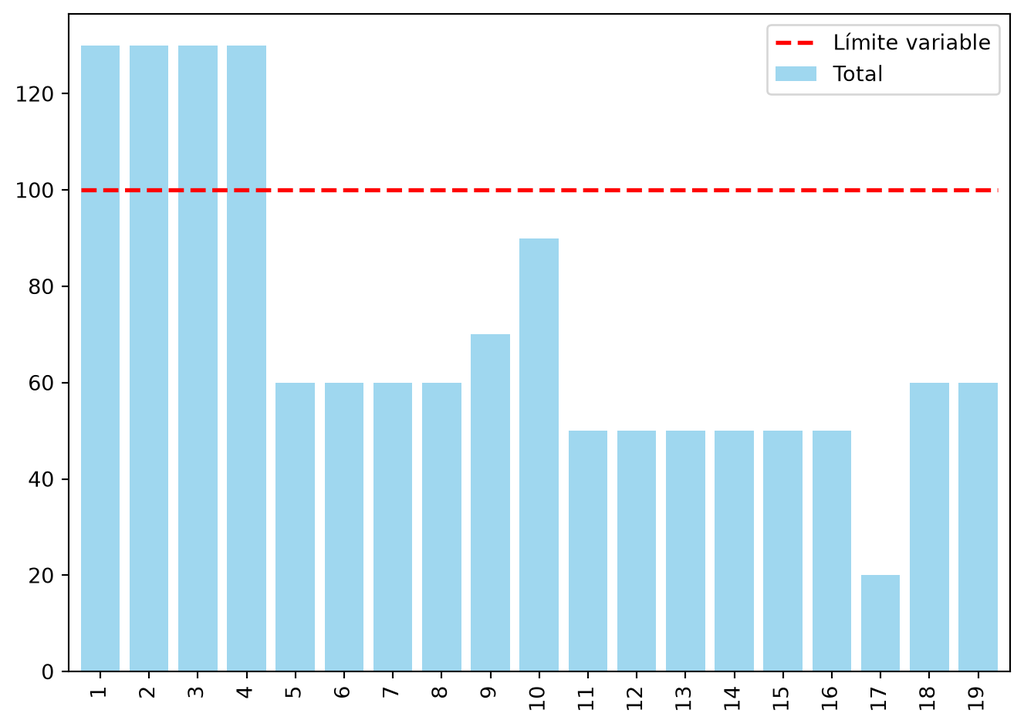

Figura 3: Diagrama de cargas de agua frente a la cuota del bando

Tabla 2: Desplazamientos de la nivelación (suma de cuadrados mínima dentro de las holguras)

|  | desplazamientos |
| --- | --- |
| C | 5 |

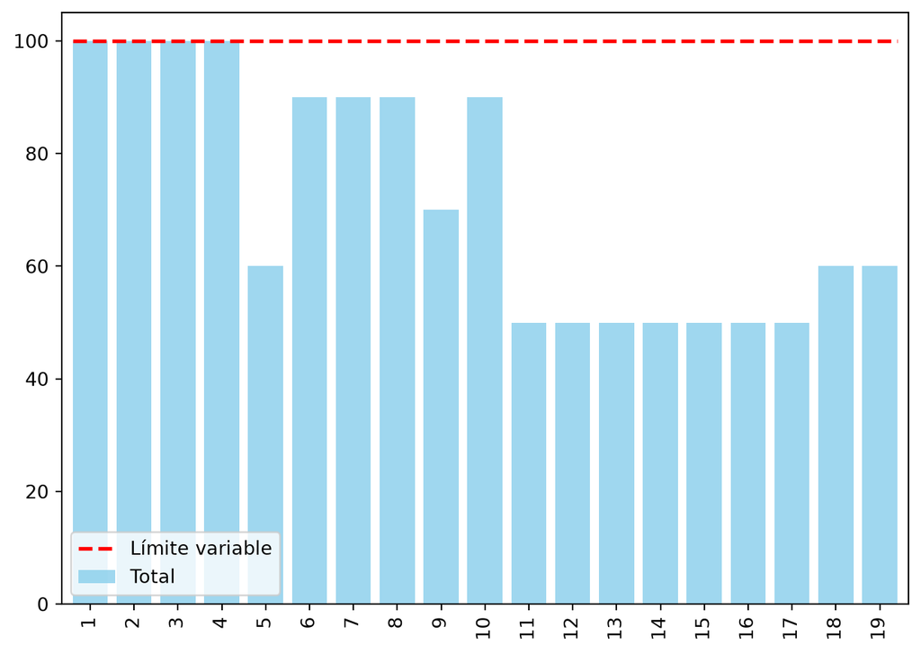

Figura 4: Diagrama de cargas de agua tras la nivelación

Tabla 3: Exceso sobre la cuota, semana a semana, antes y después de nivelar (m³)

|  | 1 | 2 | 3 | 4 | 5 | 6 | 7 | 8 | 9 | 10 | 11 | 12 | 13 | 14 | 15 | 16 | 17 | 18 | 19 | Total |
| --- | --- | --- | --- | --- | --- | --- | --- | --- | --- | --- | --- | --- | --- | --- | --- | --- | --- | --- | --- | --- |
| consumo inicial | 130 | 130 | 130 | 130 | 60 | 60 | 60 | 60 | 70 | 90 | 50 | 50 | 50 | 50 | 50 | 50 | 20 | 60 | 60 | 1360 |
| exceso inicial | 30 | 30 | 30 | 30 | 0 | 0 | 0 | 0 | 0 | 0 | 0 | 0 | 0 | 0 | 0 | 0 | 0 | 0 | 0 | 120 |
| consumo nivelado | 100 | 100 | 100 | 100 | 60 | 90 | 90 | 90 | 70 | 90 | 50 | 50 | 50 | 50 | 50 | 50 | 50 | 60 | 60 | 1360 |
| exceso nivelado | 0 | 0 | 0 | 0 | 0 | 0 | 0 | 0 | 0 | 0 | 0 | 0 | 0 | 0 | 0 | 0 | 0 | 0 | 0 | 0 |

El exceso de cada semana es máx(0, consumo − 100). Con inicios más tempranos el consumo supera la cuota en las semanas 1, 2, 3 y 4: exceso = 30 + 30 + 30 + 30 = 120 m³. La nivelación desplaza C 5 semanas (holgura total 5), con lo que Σc² baja de 117600 a 105600, sin cambiar la duración ni el volumen total (1360 m³).

**Respuesta:** pico de **130 m³** con inicios más tempranos y **100 m³** tras nivelar, frente a la cuota de 100; el exceso pasa de 120 a **0 m³**: el plan nivelado **cabe** en la cuota sin alargar el proyecto (19 semanas).

## Apartado 2

2. 1. Calcule el coste de las opciones legales: traer en cuba el exceso del plan inicial, traer en cuba el exceso del plan nivelado, y programar con asignación limitada a 100 m³ por semana (duración, retraso y penalidad). Calcule también el coste esperado de la propuesta del hidrante. ¿Cuál es la opción legal más barata?

|  | plan inicial + cuba | nivelado + cuba | asignación con límite de 100 m³ | hidrante (propuesta) |
| --- | --- | --- | --- | --- |
| agua en cuba (k€) | 1.7 | 0.0 | 0.0 | 0.0 |
| retraso (semanas; esperado en el hidrante) | 0.0 | 0.0 | 0.0 | 1.8 |
| penalidad o sanción (k€) | 0.0 | 0.0 | 0.0 | 23.4 |
| coste (k€) | 1.7 | 0.0 | 0.0 | 23.4 |

- Cuba con el plan inicial: 120 m³ × 14.0 €/m³ / 1000 = 1.68 k€.

- Cuba con el plan nivelado: 0 m³ × 14.0 / 1000 = 0.00 k€.

- Asignación con límite de 100 m³ por semana (lección 11): el proyecto dura **19** semanas, 0 semanas de retraso × 10 = 0 k€.

- Hidrante: P(detección) × (multa + semanas de corte × penalidad) = 0.9 × (6 + 2 × 10) = **23.4 k€** esperados, más que la opción legal: mal negocio además de infracción.

**Respuesta:** la opción legal más barata es **nivelar**: el plan nivelado cabe en la cuota sin cuba ni retraso (0 k€); la asignación con límite también termina en 19 semanas, sin retraso.

[figure not shown]

Figura 5: Gantt con asignación limitada a la cuota

## Apartado 3

3. 2. Según el criterio y la norma de referencia, ¿es la cuota un límite del plan o un riesgo que se acepta? ¿Cabe el plan en la cuota tras nivelar, sin retraso? ¿Es el hidrante una opción de la tabla? ¿En qué escalón de la pirámide queda cada opción?

**Norma y S16.** La cuota del bando es una limitación de uso del agua en situación excepcional (TRLA, arts. 55.2 y 58) y una condición del suministro de obra: es un **límite del plan**, con fecha y cifra, no un riesgo que se acepta pagando la penalidad. Si el plan cabe lo dice el diagrama de cargas: con inicios más tempranos el pico es de 130 m³ y el exceso de 120 m³; tras nivelar, 100 m³ y **cabe** en la cuota sin retraso. El hidrante **no es una opción de la tabla**: una toma no autorizada es infracción (TRLA, art. 116.3.b) y c); reglamento del servicio), y «si alguien pregunta es agua de la cuba» es una afirmación falsa (lección 19, C1). La opción correcta es la legal de menor coste: **nivelar**, porque el plan nivelado cabe en la cuota sin cuba ni retraso (0 k€). **S11.** La sequía sí es, además, un riesgo del proyecto: que el bando baje la cuota o cierre el punto de carga de las cubas tiene probabilidad e impacto, y entra en el registro. **S1.** El hidrante traslada el impacto a los demás usuarios de la red (ni siquiera compensa); la cuba **compensa** (el consumo es el mismo, pagado y traído de otra fuente); nivelar y asignar **minimizan** el pico sin cambiar el volumen; reducir el consumo (curado con láminas o filmógenos, reutilizar el agua de lavado) **evita** parte del impacto.

**Respuesta:** la cuota es un **límite del plan**; tras nivelar el plan **cabe** sin retraso; el hidrante **no** es una opción de la tabla (traslada el impacto); la cuba compensa, nivelar y asignar minimizan, y reducir el consumo evita.

**1. Una cuota semanal de agua fijada por el bando municipal de sequía es, para el cronograma de la obra…**

- ✅ un límite del plan, como el número de operarios: se nivela y, si no cabe, se asigna con límite o se compra el recurso fuera

- ◻️ un riesgo que se acepta si la penalidad por retraso es mayor que la sanción

- ◻️ una recomendación

- ◻️ una reserva de gestión

*S16: la cuota tiene cifra y fecha; cabe o no cabe, y lo dice el diagrama de cargas.*

**2. Tomar agua de un hidrante sin autorización durante las restricciones de sequía es…**

- ✅ una infracción (toma no autorizada; TRLA art. 116.3 y reglamento del servicio), no una opción del plan

- ◻️ una opción si se paga después el agua consumida

- ◻️ legal si el contador de obra no lo registra

- ◻️ legal de noche

*S16: obtener el recurso saltándose la limitación es infracción.*

**3. Nivelar las cargas de agua dentro de las holguras…**

- ✅ reduce el pico semanal sin cambiar el volumen total ni la duración

- ◻️ reduce el consumo total de agua

- ◻️ alarga el proyecto

- ◻️ elimina siempre el exceso sobre la cuota

*Lección 11: la nivelación mueve actividades no críticas; el volumen es el mismo.*

**4. Traer en camión cuba el agua que la cuota no permite es, en la pirámide de la sostenibilidad…**

- ✅ compensar: el mismo consumo, pagado y traído de otra fuente

- ◻️ evitar

- ◻️ minimizar

- ◻️ restaurar

*S1: el impacto no se reduce; se paga y se traslada de fuente.*

## Apartado 4

4. 3. ¿Qué propone al jefe de obra y qué comunica al cliente y al ayuntamiento? Aplique la rúbrica.

La pregunta del bloque C es abierta: no tiene una respuesta única y se evalúa el **procedimiento**: (1) identificar a todos los afectados, incluidos los que no están en la mesa (la comunidad, los trabajadores de la cadena, quien opere o desmantele lo construido, las generaciones siguientes) y qué pierde o gana cada uno con las cifras del bloque A; (2) formular al menos dos alternativas además de la propuesta, situándolas en la pirámide (compensar, restaurar, minimizar, evitar); (3) someter cada alternativa a tres pruebas —legalidad (¿cumple la norma?), publicidad (¿la defendería ante el inspector, el cliente o la prensa?) y ciclo de vida (¿quién paga el impacto y cuándo?)—; (4) decidir y redactar la comunicación con las cifras. Una respuesta que sólo opina, sin cifras ni alternativas, no supera la rúbrica.

Al jefe de obra: la tabla del apartado 2 y el plan nivelado con el calendario de riegos y curados semana a semana; las medidas de reducción (curado con láminas, agua de lavado recirculada) para bajar el consumo, no sólo el pico; y la cuba o la asignación limitada para lo que no quepa, con su coste (0.0 k€ en la opción elegida). Al cliente: la cuota del bando, el plan elegido y su efecto en la entrega. Al ayuntamiento, si hace falta: la solicitud motivada de una cuota mayor para las semanas de hormigonado, con el diagrama de cargas como justificación. Prueba de publicidad: ¿explicaría al concejal, en plena sequía, la manguera del hidrante «porque el contador no lo ve»?